# Object Detection

**Objectives:**

- Practising local image features and classifiers for object detection from still images and videos
- Working with two case studies: face detection and pedestrian detection

# 1. Face detection

## 1.1. Face detection from still images

```python
import cv2 as cv
def detect_face(image, cascade_detector):
    #convert input image to grayscale
    image_gray = cv.cvtColor(image, cv.COLOR_BGR2GRAY)
    faces = cascade_detector.detectMultiScale(image_gray,
                                              scaleFactor = 1.1, #the ratio between two consecutive scales
                                              minNeighbors = 5, #minimum number of overlapping windows to be considered
                                              minSize = (30, 30), #minimum size of detection window (in pixels)
                                              flags = cv.CASCADE_SCALE_IMAGE) #scale the image rather than detection window
    return faces
```

```python
import time

image = cv.imread('FaceImages/abba.png')
cascade_detector = cv.CascadeClassifier('haarcascade_frontalface_default.xml')

start_time = time.time()
faces = detect_face(image, cascade_detector)
print('Face detection is performed in %s seconds ---' % (time.time() - start_time))
```

```
Face detection is performed in 0.4992716312408447 seconds ---
```

### To find the number of detected faces, we perform:

```python
if (faces is not None):
    print('Found ', len(faces), ' faces')
else:
    print('There is no face found!')
```

```
Found  4  faces
```

### To visualise the detection results, we perform:

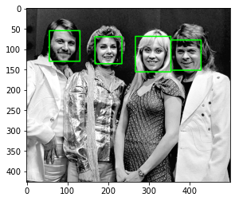

```python
from matplotlib import pyplot as plt

for (x, y, w, h) in faces:
    #(x, y) are the coordinate of the topleft corner,
    # w, h are the width and height of the bounding box
    cv.rectangle(image, (x, y), (x + w, y + h), (0, 255, 0), 2)

plt.imshow(image[:,:,::-1]) # RGB-> BGR
```

```python
def detect_face11(image, cascade_detector):
    #convert input image to grayscale
    image_gray = cv.cvtColor(image, cv.COLOR_BGR2GRAY)
    faces = cascade_detector.detectMultiScale(image_gray,
                                              scaleFactor = 1.2, #the ratio between two consecutive scales
                                              minNeighbors = 0, #minimum number of overlapping windows to be considered
                                              minSize = (10, 10), #minimum size of detection window (in pixels)
                                              flags = cv.CASCADE_SCALE_IMAGE) #scale the image rather than detection window
    return faces
```

```python
image11 = cv.imread('FaceImages/img_1014.jpg')
cascade_detector = cv.CascadeClassifier('haarcascade_frontalface_default.xml')

start_time = time.time()
faces = detect_face11(image11, cascade_detector)
print('Face detection is performed in %s seconds ---' % (time.time() - start_time))
```

```
Face detection is performed in 0.01894974708557129 seconds ---
```

```python
if (faces is not None):
    print('Found ', len(faces), ' faces')
else:
    print('There is no face found!')
```

```
Found  63  faces
```

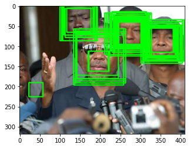

```python
for (x, y, w, h) in faces:
    #(x, y) are the coordinate of the topleft corner,
    # w, h are the width and height of the bounding box
    cv.rectangle(image11, (x, y), (x + w, y + h), (0, 255, 0), 2)

plt.imshow(image11[:,:,::-1]) # RGB-> BGR
```

```python
image12 = cv.imread('FaceImages/img_1123.jpg')
cascade_detector = cv.CascadeClassifier('haarcascade_frontalface_default.xml')

start_time = time.time()
faces = detect_face11(image12, cascade_detector)
print('Face detection is performed in %s seconds ---' % (time.time() - start_time))
```

```
Face detection is performed in 0.015798091888427734 seconds ---
```

```python
if (faces is not None):
    print('Found ', len(faces), ' faces')
else:
    print('There is no face found!')
```

```
Found  27  faces
```

[figure not shown]

```python
for (x, y, w, h) in faces:
    #(x, y) are the coordinate of the topleft corner,
    # w, h are the width and height of the bounding box
    cv.rectangle(image12, (x, y), (x + w, y + h), (0, 255, 0), 2)

plt.imshow(image12[:,:,::-1]) # RGB-> BGR
```

```python
def detect_face12(image, cascade_detector):
    #convert input image to grayscale
    image_gray = cv.cvtColor(image, cv.COLOR_BGR2GRAY)
    faces = cascade_detector.detectMultiScale(image_gray,
                                              scaleFactor = 1.3, #the ratio between two consecutive scales
                                              minNeighbors = 10, #minimum number of overlapping windows to be considered
                                              minSize = (20, 20), #minimum size of detection window (in pixels)
                                              flags = cv.CASCADE_SCALE_IMAGE) #scale the image rather than detection window
    return faces
```

```python
image13 = cv.imread('FaceImages/img_1014.jpg')
cascade_detector = cv.CascadeClassifier('haarcascade_frontalface_default.xml')

start_time = time.time()
faces = detect_face12(image13, cascade_detector)
print('Face detection is performed in %s seconds ---' % (time.time() - start_time))
```

```
Face detection is performed in 0.014511823654174805 seconds ---
```

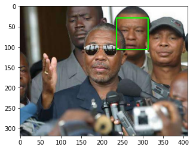

```python
for (x, y, w, h) in faces:
    #(x, y) are the coordinate of the topleft corner,
    # w, h are the width and height of the bounding box
    cv.rectangle(image13, (x, y), (x + w, y + h), (0, 255, 0), 2)

plt.imshow(image13[:,:,::-1]) # RGB-> BGR
```

```python
image14 = cv.imread('FaceImages/img_1123.jpg')
cascade_detector = cv.CascadeClassifier('haarcascade_frontalface_default.xml')

start_time = time.time()
faces = detect_face12(image14, cascade_detector)
print('Face detection is performed in %s seconds ---' % (time.time() - start_time))
```

```
Face detection is performed in 0.012558937072753906 seconds ---
```

[figure not shown]

```python
for (x, y, w, h) in faces:
    #(x, y) are the coordinate of the topleft corner,
    # w, h are the width and height of the bounding box
    cv.rectangle(image14, (x, y), (x + w, y + h), (0, 255, 0), 2)

plt.imshow(image14[:,:,::-1]) # RGB-> BGR
```

```python
def detect_face13(image, cascade_detector):
    #convert input image to grayscale
    image_gray = cv.cvtColor(image, cv.COLOR_BGR2GRAY)
    faces = cascade_detector.detectMultiScale(image_gray,
                                              scaleFactor = 1.4, #the ratio between two consecutive scales
                                              minNeighbors = 15, #minimum number of overlapping windows to be considered
                                              minSize = (40, 40), #minimum size of detection window (in pixels)
                                              flags = cv.CASCADE_SCALE_IMAGE) #scale the image rather than detection window
    return faces
```

```python
image15 = cv.imread('FaceImages/img_1014.jpg')
cascade_detector = cv.CascadeClassifier('haarcascade_frontalface_default.xml')

start_time = time.time()
faces = detect_face13(image15, cascade_detector)
print('Face detection is performed in %s seconds ---' % (time.time() - start_time))
```

```
Face detection is performed in 0.007516145706176758 seconds ---
```

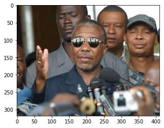

```python
for (x, y, w, h) in faces:
    #(x, y) are the coordinate of the topleft corner,
    # w, h are the width and height of the bounding box
    cv.rectangle(image15, (x, y), (x + w, y + h), (0, 255, 0), 2)

plt.imshow(image15[:,:,::-1]) # RGB-> BGR
```

```python
image16 = cv.imread('FaceImages/img_1123.jpg')
cascade_detector = cv.CascadeClassifier('haarcascade_frontalface_default.xml')

start_time = time.time()
faces = detect_face13(image16, cascade_detector)
print('Face detection is performed in %s seconds ---' % (time.time() - start_time))
```

```
Face detection is performed in 0.0061893463134765625 seconds ---
```

[figure not shown]

```python
for (x, y, w, h) in faces:
    #(x, y) are the coordinate of the topleft corner,
    # w, h are the width and height of the bounding box
    cv.rectangle(image16, (x, y), (x + w, y + h), (0, 255, 0), 2)

plt.imshow(image16[:,:,::-1]) # RGB-> BGR
```

```python
def detect_face14(image, cascade_detector):
    #convert input image to grayscale
    image_gray = cv.cvtColor(image, cv.COLOR_BGR2GRAY)
    faces = cascade_detector.detectMultiScale(image_gray,
                                              scaleFactor = 1.5, #the ratio between two consecutive scales
                                              minNeighbors = 20, #minimum number of overlapping windows to be considered
                                              minSize = (50, 50), #minimum size of detection window (in pixels)
                                              flags = cv.CASCADE_SCALE_IMAGE) #scale the image rather than detection window
    return faces
```

```python
image17 = cv.imread('FaceImages/img_1014.jpg')
cascade_detector = cv.CascadeClassifier('haarcascade_frontalface_default.xml')

start_time = time.time()
faces = detect_face14(image17, cascade_detector)
print('Face detection is performed in %s seconds ---' % (time.time() - start_time))
```

```
Face detection is performed in 0.0072100162506103516 seconds ---
```

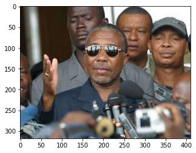

```python
for (x, y, w, h) in faces:
    #(x, y) are the coordinate of the topleft corner,
    # w, h are the width and height of the bounding box
    cv.rectangle(image17, (x, y), (x + w, y + h), (0, 255, 0), 2)

plt.imshow(image17[:,:,::-1]) # RGB-> BGR
```

```python
image18 = cv.imread('FaceImages/img_1123.jpg')
cascade_detector = cv.CascadeClassifier('haarcascade_frontalface_default.xml')

start_time = time.time()
faces = detect_face14(image18, cascade_detector)
print('Face detection is performed in %s seconds ---' % (time.time() - start_time))
```

```
Face detection is performed in 0.007978439331054688 seconds ---
```

[figure not shown]

```python
for (x, y, w, h) in faces:
    #(x, y) are the coordinate of the topleft corner,
    # w, h are the width and height of the bounding box
    cv.rectangle(image18, (x, y), (x + w, y + h), (0, 255, 0), 2)

plt.imshow(image18[:,:,::-1]) # RGB-> BGR
```

```python
def detect_face15(image, cascade_detector):
    #convert input image to grayscale
    image_gray = cv.cvtColor(image, cv.COLOR_BGR2GRAY)
    faces = cascade_detector.detectMultiScale(image_gray,
                                              scaleFactor = 1.1, #the ratio between two consecutive scales
                                              minNeighbors = 5, #minimum number of overlapping windows to be considered
                                              minSize = (30, 30), #minimum size of detection window (in pixels)
                                              flags = cv.CASCADE_SCALE_IMAGE) #scale the image rather than detection window
    return faces
```

```python
image19 = cv.imread('FaceImages/img_1014.jpg')
cascade_detector = cv.CascadeClassifier('haarcascade_frontalface_default.xml')

start_time = time.time()
faces = detect_face15(image19, cascade_detector)
print('Face detection is performed in %s seconds ---' % (time.time() - start_time))
```

```
Face detection is performed in 0.02393484115600586 seconds ---
```

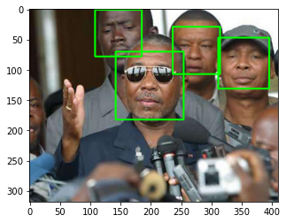

```python
for (x, y, w, h) in faces:
    #(x, y) are the coordinate of the topleft corner,
    # w, h are the width and height of the bounding box
    cv.rectangle(image19, (x, y), (x + w, y + h), (0, 255, 0), 2)

plt.imshow(image19[:,:,::-1]) # RGB-> BGR
```

```python
image20 = cv.imread('FaceImages/img_1123.jpg')
cascade_detector = cv.CascadeClassifier('haarcascade_frontalface_default.xml')

start_time = time.time()
faces = detect_face15(image20, cascade_detector)
print('Face detection is performed in %s seconds ---' % (time.time() - start_time))
```

```
Face detection is performed in 0.02428913116455078 seconds ---
```

[figure not shown]

```python
for (x, y, w, h) in faces:
    #(x, y) are the coordinate of the topleft corner,
    # w, h are the width and height of the bounding box
    cv.rectangle(image20, (x, y), (x + w, y + h), (0, 255, 0), 2)

plt.imshow(image20[:,:,::-1]) # RGB-> BGR
```

The best parameters to the cascade_detector to detect human faces in 'images img_1014.jpg' and 'img_1123.jpg' are:

- scaleFactor = 1.1, minNeighbors = 5, minSize = (30, 30)

**In image 'img_1014.jpg', 2 faces in extreme left and right were not detected because they are cropped and aligned in different angles that our algorithm can't detect. In image 'img_1123.jpg', 2 faces in extreme left and right were not detected because both the faces are not fully visible and at different angles from which our algorithm is not able to detect the faces.**

- when we used: scaleFactor = 1.2, minNeighbors = 0, minSize = (10, 10)

**We can see that a total of 63 faces were detected in image 'images img_1014.jpg' and 27 faces were detected in image 'img_1123.jpg' because the as there are no min. number of overlapping windows to be considered and also the min. size of detection window (in pixels) is very small that it detects a lot of faces which contributes to large error.**

- when we used: scaleFactor = 1.5, minNeighbors = 20, minSize = (50, 50) & scaleFactor = 1.4, minNeighbors = 15, minSize = (40, 40)

**We can see that no faces were detected in both the cases as the scale factor which is the ratio between two consecutive scales is too high, the minimum number of overlapping windows to be considered is also too high & the minimum size of detection window (in pixels) is very large so faces were detected.**

- when we used: scaleFactor = 1.3, minNeighbors = 10, minSize = (20, 20)

**We can see that in both the images only 1 face is detected as the scale factor is large which determines the ratio between two consecutive scales in the pyramid level, the minimum number of overlapping windows to be considered is also too high.**

## 1.2. Face detection from video

```python
import cv2 as cv
import os

#initialise webcam
cam = cv.VideoCapture(0)

#initialise cascade_detector
cascade_detector = cv.CascadeClassifier('haarcascade_frontalface_default.xml')

while True:
    #read the image from the cam
    _, image = cam.read()

    #detect human faces from the current image using the cascade_detector
    faces = detect_face(image, cascade_detector)

    #display detected faces
    for x, y, w, h in faces:
        cv.rectangle(image, (x, y), (x + w, y + h), color = (0, 255, 0))
    cv.imshow('face detection demo', image)

    if cv.waitKey(1) == ord("q"):
        cv.destroyAllWindows()
        break

cam.release()
```

## 2. Pedestrian detection

This work makes use of HOG as image features and SVM as classifier. The following detect_pedestrian method receives input as a colour image, then detects pedestrians from the input image, and returns a list of detected pedestrians (if any).

```python
import cv2 as cv
import numpy as np
import imutils
from imutils.object_detection import non_max_suppression

def nms(boxes):
    #We first convert boxes from list to array as required by non_max_suppression method
    #In addition, each box in the array is encoded by the topleft and bottomright corners
    boxes_array = np.array([[x, y, x + w, y + h] for (x, y, w, h) in boxes])
    boxes_array = non_max_suppression(boxes_array, probs = None, overlapThresh = 0.65)

    #create a new list of boxes to store results
    boxes_list = []

    for top_x, top_y, bottom_x, bottom_y in boxes_array:
        boxes_list.append([top_x, top_y, bottom_x - top_x, bottom_y - top_y])

    return boxes_list

def detect_pedestrian(image):
    #initialise the HOG descriptor and SVM classifier
    hog = cv.HOGDescriptor()
    hog.setSVMDetector(cv.HOGDescriptor_getDefaultPeopleDetector())

    image_resized = imutils.resize(image,
                                   width = min(400, image.shape[1])) #resize the input image so that the width is max by 400

    image_scale = image.shape[1] / image_resized.shape[1]

    #detect pedestrians
    (boxes, _) = hog.detectMultiScale(image_resized,
                                      winStride = (4, 4), #horizontal and vertical stride
                                      padding = (6, 6), #horizontal and vertical padding for each window
                                      scale = 1.05) #scale factor between two consecutive scales

    #non-maximum suppression
    boxes = nms(boxes)

    #resize the bounding boxes
    for box in boxes:
        box[0] = np.int(box[0] * image_scale)
        box[1] = np.int(box[1] * image_scale)
        box[2] = np.int(box[2] * image_scale)
        box[3] = np.int(box[3] * image_scale)

    return boxes
```

**We test the above detect_pedestrian method with the images in PedestrianImages as follows**

```python
import time

image = cv.imread('PedestrianImages/person_029.png')

start_time = time.time()
pedestrians = detect_pedestrian(image)
print('Pedestrian detection is performed in %s seconds ---' % (time.time() - start_time))
```

```
Pedestrian detection is performed in 0.16256165504455566 seconds ---
```

### We show the detection results using the following code:

```
Found  1  pedestrians
```

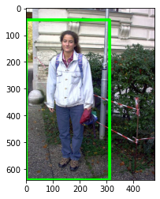

```python
from matplotlib import pyplot as plt

if (pedestrians is not None):
    print('Found ', len(pedestrians), ' pedestrians')

    for (x, y, w, h) in pedestrians:
        cv.rectangle(image, (x, y), (x + w, y + h), (0, 255, 0), 10)

    plt.imshow(image[:,:,::-1]) # RGB-> BGR

else:
    print('There is no pedestrian found!')
```

```python
def nms(boxes):
    #We first convert boxes from list to array as required by non_max_suppression method
    #In addition, each box in the array is encoded by the topleft and bottomright corners
    boxes_array = np.array([[x, y, x + w, y + h] for (x, y, w, h) in boxes])
    boxes_array = non_max_suppression(boxes_array, probs = None, overlapThresh = 0.65)

    #create a new list of boxes to store results
    boxes_list = []

    for top_x, top_y, bottom_x, bottom_y in boxes_array:
        boxes_list.append([top_x, top_y, bottom_x - top_x, bottom_y - top_y])

    return boxes_list

def detect_pedestrian(image):
    #initialise the HOG descriptor and SVM classifier
    hog = cv.HOGDescriptor()
    hog.setSVMDetector(cv.HOGDescriptor_getDefaultPeopleDetector())

    image_resized = imutils.resize(image,
                                   width = min(400, image.shape[1])) #resize the input image so that the width is max by 400

    image_scale = image.shape[1] / image_resized.shape[1]

    #detect pedestrians
    (boxes, _) = hog.detectMultiScale(image_resized,
                                      winStride = (4, 4), #horizontal and vertical stride
                                      padding = (6, 6), #horizontal and vertical padding for each window
                                      scale = 1.05) #scale factor between two consecutive scales

    #non-maximum suppression
    #boxes = nms(boxes)

    #resize the bounding boxes
    for box in boxes:
        box[0] = np.int(box[0] * image_scale)
        box[1] = np.int(box[1] * image_scale)
        box[2] = np.int(box[2] * image_scale)
        box[3] = np.int(box[3] * image_scale)

    return boxes
```

```python
import time

image = cv.imread('PedestrianImages/person_029.png')

start_time = time.time()
pedestrians = detect_pedestrian(image)
print('Pedestrian detection is performed in %s seconds ---' % (time.time() - start_time))
```

```
Pedestrian detection is performed in 0.16142964363098145 seconds ---
```

```
Found  4  pedestrians
```

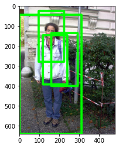

```python
from matplotlib import pyplot as plt

if (pedestrians is not None):
    print('Found ', len(pedestrians), ' pedestrians')

    for (x, y, w, h) in pedestrians:
        cv.rectangle(image, (x, y), (x + w, y + h), (0, 255, 0), 10)

    plt.imshow(image[:,:,::-1]) # RGB-> BGR

else:
    print('There is no pedestrian found!')
```

**Here we got a lot of overlapping windows because we haven't used the 'nms (non-maximum suppression)', which is used to merge the overlapping boxes that we get after hog.detectMultiScale() function.**

```python
def nms(boxes):
    #We first convert boxes from list to array as required by non_max_suppression method
    #In addition, each box in the array is encoded by the topleft and bottomright corners
    boxes_array = np.array([[x, y, x + w, y + h] for (x, y, w, h) in boxes])
    boxes_array = non_max_suppression(boxes_array, probs = None, overlapThresh = 0.65)

    #create a new list of boxes to store results
    boxes_list = []

    for top_x, top_y, bottom_x, bottom_y in boxes_array:
        boxes_list.append([top_x, top_y, bottom_x - top_x, bottom_y - top_y])

    return boxes_list

def detect_pedestrian(image):
    #initialise the HOG descriptor and SVM classifier
    hog = cv.HOGDescriptor()
    hog.setSVMDetector(cv.HOGDescriptor_getDefaultPeopleDetector())

    image_resized = imutils.resize(image,
                                   width = min(400, image.shape[1])) #resize the input image so that the width is max by 400

    image_scale = image.shape[1] / image_resized.shape[1]

    #detect pedestrians
    (boxes, _) = hog.detectMultiScale(image_resized,
                                      winStride = (2, 2), #horizontal and vertical stride
                                      padding = (4, 4), #horizontal and vertical padding for each window
                                      scale = 1.05) #scale factor between two consecutive scales

    #non-maximum suppression
    boxes = nms(boxes)

    #resize the bounding boxes
    for box in boxes:
        box[0] = np.int(box[0] * image_scale)
        box[1] = np.int(box[1] * image_scale)
        box[2] = np.int(box[2] * image_scale)
        box[3] = np.int(box[3] * image_scale)

    return boxes
```

```python
import time

image = cv.imread('PedestrianImages/person_029.png')

start_time = time.time()
pedestrians = detect_pedestrian(image)
print('Pedestrian detection is performed in %s seconds ---' % (time.time() - start_time))
```

```
Pedestrian detection is performed in 0.5544695854187012 seconds ---
```

```
Found  3  pedestrians
```

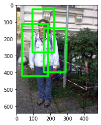

```python
from matplotlib import pyplot as plt

if (pedestrians is not None):
    print('Found ', len(pedestrians), ' pedestrians')

    for (x, y, w, h) in pedestrians:
        cv.rectangle(image, (x, y), (x + w, y + h), (0, 255, 0), 10)

    plt.imshow(image[:,:,::-1]) # RGB-> BGR

else:
    print('There is no pedestrian found!')
```

```python
import time

image = cv.imread('PedestrianImages/person_032.png')

start_time = time.time()
pedestrians = detect_pedestrian(image)
print('Pedestrian detection is performed in %s seconds ---' % (time.time() - start_time))
```

```
Pedestrian detection is performed in 0.535167932510376 seconds ---
```

```
Found  1  pedestrians
```

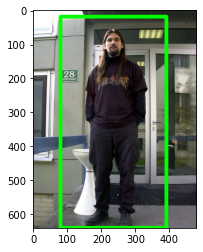

```python
from matplotlib import pyplot as plt

if (pedestrians is not None):
    print('Found ', len(pedestrians), ' pedestrians')

    for (x, y, w, h) in pedestrians:
        cv.rectangle(image, (x, y), (x + w, y + h), (0, 255, 0), 10)

    plt.imshow(image[:,:,::-1]) # RGB-> BGR

else:
    print('There is no pedestrian found!')
```

```python
def nms(boxes):
    #We first convert boxes from list to array as required by non_max_suppression method
    #In addition, each box in the array is encoded by the topleft and bottomright corners
    boxes_array = np.array([[x, y, x + w, y + h] for (x, y, w, h) in boxes])
    boxes_array = non_max_suppression(boxes_array, probs = None, overlapThresh = 0.65)

    #create a new list of boxes to store results
    boxes_list = []

    for top_x, top_y, bottom_x, bottom_y in boxes_array:
        boxes_list.append([top_x, top_y, bottom_x - top_x, bottom_y - top_y])

    return boxes_list

def detect_pedestrian(image):
    #initialise the HOG descriptor and SVM classifier
    hog = cv.HOGDescriptor()
    hog.setSVMDetector(cv.HOGDescriptor_getDefaultPeopleDetector())

    image_resized = imutils.resize(image,
                                   width = min(400, image.shape[1])) #resize the input image so that the width is max by 400

    image_scale = image.shape[1] / image_resized.shape[1]

    #detect pedestrians
    (boxes, _) = hog.detectMultiScale(image_resized,
                                      winStride = (4, 4), #horizontal and vertical stride
                                      padding = (6, 6), #horizontal and vertical padding for each window
                                      scale = 1.1) #scale factor between two consecutive scales

    #non-maximum suppression
    boxes = nms(boxes)

    #resize the bounding boxes
    for box in boxes:
        box[0] = np.int(box[0] * image_scale)
        box[1] = np.int(box[1] * image_scale)
        box[2] = np.int(box[2] * image_scale)
        box[3] = np.int(box[3] * image_scale)

    return boxes
```

```python
import time

image = cv.imread('PedestrianImages/person_029.png')

start_time = time.time()
pedestrians = detect_pedestrian(image)
print('Pedestrian detection is performed in %s seconds ---' % (time.time() - start_time))
```

```
Pedestrian detection is performed in 0.1413872241973877 seconds ---
```

```
Found  1  pedestrians
```

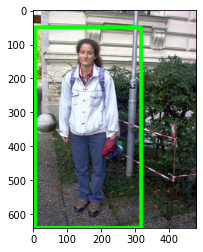

```python
from matplotlib import pyplot as plt

if (pedestrians is not None):
    print('Found ', len(pedestrians), ' pedestrians')

    for (x, y, w, h) in pedestrians:
        cv.rectangle(image, (x, y), (x + w, y + h), (0, 255, 0), 10)

    plt.imshow(image[:,:,::-1]) # RGB-> BGR

else:
    print('There is no pedestrian found!')
```

```python
import time

image = cv.imread('PedestrianImages/person_265.png')

start_time = time.time()
pedestrians = detect_pedestrian(image)
print('Pedestrian detection is performed in %s seconds ---' % (time.time() - start_time))
```

```
Pedestrian detection is performed in 0.04307103157043457 seconds ---
```

```
Found  4  pedestrians
```

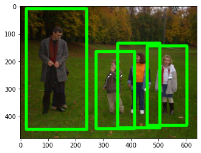

```python
from matplotlib import pyplot as plt

if (pedestrians is not None):
    print('Found ', len(pedestrians), ' pedestrians')

    for (x, y, w, h) in pedestrians:
        cv.rectangle(image, (x, y), (x + w, y + h), (0, 255, 0), 10)

    plt.imshow(image[:,:,::-1]) # RGB-> BGR

else:
    print('There is no pedestrian found!')
```

```python
def nms(boxes):
    #We first convert boxes from list to array as required by non_max_suppression method
    #In addition, each box in the array is encoded by the topleft and bottomright corners
    boxes_array = np.array([[x, y, x + w, y + h] for (x, y, w, h) in boxes])
    boxes_array = non_max_suppression(boxes_array, probs = None, overlapThresh = 0.65)

    #create a new list of boxes to store results
    boxes_list = []

    for top_x, top_y, bottom_x, bottom_y in boxes_array:
        boxes_list.append([top_x, top_y, bottom_x - top_x, bottom_y - top_y])

    return boxes_list

def detect_pedestrian(image):
    #initialise the HOG descriptor and SVM classifier
    hog = cv.HOGDescriptor()
    hog.setSVMDetector(cv.HOGDescriptor_getDefaultPeopleDetector())

    image_resized = imutils.resize(image,
                                   width = min(400, image.shape[1])) #resize the input image so that the width is max by 400

    image_scale = image.shape[1] / image_resized.shape[1]

    #detect pedestrians
    (boxes, _) = hog.detectMultiScale(image_resized,
                                      winStride = (6, 6), #horizontal and vertical stride
                                      padding = (8, 8), #horizontal and vertical padding for each window
                                      scale = 1.15) #scale factor between two consecutive scales

    #non-maximum suppression
    boxes = nms(boxes)

    #resize the bounding boxes
    for box in boxes:
        box[0] = np.int(box[0] * image_scale)
        box[1] = np.int(box[1] * image_scale)
        box[2] = np.int(box[2] * image_scale)
        box[3] = np.int(box[3] * image_scale)

    return boxes
```

```python
import time

image = cv.imread('PedestrianImages/person_029.png')

start_time = time.time()
pedestrians = detect_pedestrian(image)
print('Pedestrian detection is performed in %s seconds ---' % (time.time() - start_time))
```

```
Pedestrian detection is performed in 0.11069583892822266 seconds ---
```

```
Found  0  pedestrians
```

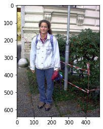

```python
from matplotlib import pyplot as plt

if (pedestrians is not None):
    print('Found ', len(pedestrians), ' pedestrians')

    for (x, y, w, h) in pedestrians:
        cv.rectangle(image, (x, y), (x + w, y + h), (0, 255, 0), 10)

    plt.imshow(image[:,:,::-1]) # RGB-> BGR

else:
    print('There is no pedestrian found!')
```

```python
import time

image = cv.imread('PedestrianImages/person_230.png')

start_time = time.time()
pedestrians = detect_pedestrian(image)
print('Pedestrian detection is performed in %s seconds ---' % (time.time() - start_time))
```

```
Pedestrian detection is performed in 0.06978201866149902 seconds ---
```

```
Found  3  pedestrians
```

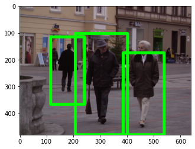

```python
from matplotlib import pyplot as plt

if (pedestrians is not None):
    print('Found ', len(pedestrians), ' pedestrians')

    for (x, y, w, h) in pedestrians:
        cv.rectangle(image, (x, y), (x + w, y + h), (0, 255, 0), 10)

    plt.imshow(image[:,:,::-1]) # RGB-> BGR

else:
    print('There is no pedestrian found!')
```

```python
def nms(boxes):
    #We first convert boxes from list to array as required by non_max_suppression method
    #In addition, each box in the array is encoded by the topleft and bottomright corners
    boxes_array = np.array([[x, y, x + w, y + h] for (x, y, w, h) in boxes])
    boxes_array = non_max_suppression(boxes_array, probs = None, overlapThresh = 0.65)

    #create a new list of boxes to store results
    boxes_list = []

    for top_x, top_y, bottom_x, bottom_y in boxes_array:
        boxes_list.append([top_x, top_y, bottom_x - top_x, bottom_y - top_y])

    return boxes_list

def detect_pedestrian(image):
    #initialise the HOG descriptor and SVM classifier
    hog = cv.HOGDescriptor()
    hog.setSVMDetector(cv.HOGDescriptor_getDefaultPeopleDetector())

    image_resized = imutils.resize(image,
                                   width = min(400, image.shape[1])) #resize the input image so that the width is max by 400

    image_scale = image.shape[1] / image_resized.shape[1]

    #detect pedestrians
    (boxes, _) = hog.detectMultiScale(image_resized,
                                      winStride = (8, 8), #horizontal and vertical stride
                                      padding = (10, 10), #horizontal and vertical padding for each window
                                      scale = 1.2) #scale factor between two consecutive scales

    #non-maximum suppression
    boxes = nms(boxes)

    #resize the bounding boxes
    for box in boxes:
        box[0] = np.int(box[0] * image_scale)
        box[1] = np.int(box[1] * image_scale)
        box[2] = np.int(box[2] * image_scale)
        box[3] = np.int(box[3] * image_scale)

    return boxes
```

```python
import time

image = cv.imread('PedestrianImages/person_029.png')

start_time = time.time()
pedestrians = detect_pedestrian(image)
print('Pedestrian detection is performed in %s seconds ---' % (time.time() - start_time))
```

```
Pedestrian detection is performed in 0.03170061111450195 seconds ---
```

```
Found  0  pedestrians
```

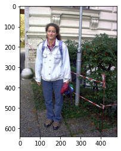

```python
from matplotlib import pyplot as plt

if (pedestrians is not None):
    print('Found ', len(pedestrians), ' pedestrians')

    for (x, y, w, h) in pedestrians:
        cv.rectangle(image, (x, y), (x + w, y + h), (0, 255, 0), 10)

    plt.imshow(image[:,:,::-1]) # RGB-> BGR

else:
    print('There is no pedestrian found!')
```

```python
import time

image = cv.imread('PedestrianImages/person_032.png')

start_time = time.time()
pedestrians = detect_pedestrian(image)
print('Pedestrian detection is performed in %s seconds ---' % (time.time() - start_time))
```

```
Pedestrian detection is performed in 0.02044677734375 seconds ---
```

```
Found  0  pedestrians
```

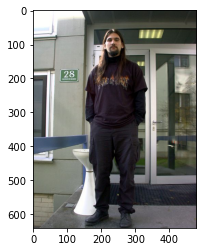

```python
from matplotlib import pyplot as plt

if (pedestrians is not None):
    print('Found ', len(pedestrians), ' pedestrians')

    for (x, y, w, h) in pedestrians:
        cv.rectangle(image, (x, y), (x + w, y + h), (0, 255, 0), 10)

    plt.imshow(image[:,:,::-1]) # RGB-> BGR

else:
    print('There is no pedestrian found!')
```

```python
import time

image = cv.imread('PedestrianImages/person_236.png')

start_time = time.time()
pedestrians = detect_pedestrian(image)
print('Pedestrian detection is performed in %s seconds ---' % (time.time() - start_time))
```

```
Pedestrian detection is performed in 0.013370275497436523 seconds ---
```

```
Found  4  pedestrians
```

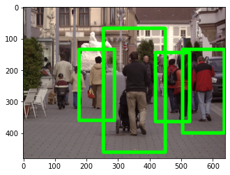

```python
from matplotlib import pyplot as plt

if (pedestrians is not None):
    print('Found ', len(pedestrians), ' pedestrians')

    for (x, y, w, h) in pedestrians:
        cv.rectangle(image, (x, y), (x + w, y + h), (0, 255, 0), 10)

    plt.imshow(image[:,:,::-1]) # RGB-> BGR

else:
    print('There is no pedestrian found!')
```